# Quiz week2

Rok Bohinc

July 8, 2019

## Question 1

Load the Alzheimer’s disease data using the commands:

```r
library(AppliedPredictiveModeling)
data(AlzheimerDisease)
```

Which of the following commands will create non-overlapping training and test sets with about 50% of the observations assigned to each?

```r
library(caret)
adData = data.frame(diagnosis,predictors)
testIndex = createDataPartition(diagnosis, p = 0.50,list=FALSE)
training = adData[-testIndex,]
testing = adData[testIndex,]
dim(training)
```

```
## [1] 166 131
```

```r
dim(testing)
```

```
## [1] 167 131
```

## Question 2

Load the cement data using the commands:

```r
library(AppliedPredictiveModeling)
data(concrete)
library(caret)
set.seed(1000)
inTrain = createDataPartition(mixtures$CompressiveStrength, p = 3/4)[[1]]
training = mixtures[ inTrain,]
testing = mixtures[-inTrain,]
summary(training)
```

```
##      Cement        BlastFurnaceSlag       FlyAsh            Water
##  Min.   :0.04482   Min.   :0.000000   Min.   :0.00000   Min.   :0.05139
##  1st Qu.:0.08535   1st Qu.:0.000000   1st Qu.:0.00000   1st Qu.:0.06957
##  Median :0.11682   Median :0.009416   Median :0.00000   Median :0.07848
##  Mean   :0.12044   Mean   :0.031369   Mean   :0.02266   Mean   :0.07761
##  3rd Qu.:0.14904   3rd Qu.:0.061616   3rd Qu.:0.05029   3rd Qu.:0.08378
##  Max.   :0.22541   Max.   :0.150339   Max.   :0.08884   Max.   :0.11216
##  Superplasticizer   CoarseAggregate  FineAggregate         Age
##  Min.   :0.000000   Min.   :0.3459   Min.   :0.2480   Min.   :  1.00
##  1st Qu.:0.000000   1st Qu.:0.3927   1st Qu.:0.3112   1st Qu.:  7.00
##  Median :0.002723   Median :0.4205   Median :0.3301   Median : 28.00
##  Mean   :0.002602   Mean   :0.4152   Mean   :0.3301   Mean   : 45.41
##  3rd Qu.:0.004396   3rd Qu.:0.4376   3rd Qu.:0.3541   3rd Qu.: 56.00
##  Max.   :0.013149   Max.   :0.4798   Max.   :0.4141   Max.   :365.00
##  CompressiveStrength
##  Min.   : 3.32
##  1st Qu.:23.71
##  Median :34.45
##  Mean   :35.80
##  3rd Qu.:46.13
##  Max.   :81.75
```

Make a plot of the outcome (CompressiveStrength) versus the index of the samples. Color by each of the variables in the data set (you may find the cut2() function in the Hmisc package useful for turning continuous covariates into factors). What do you notice in these plots?

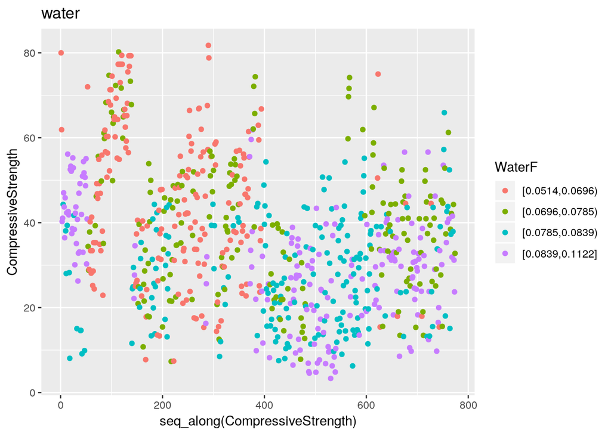

```r
library(Hmisc)
library(ggplot2)
training$WaterF <- cut2(training$Water,g=4)
training$CementF <- cut2(training$Cement,g=4)
training$BlastFurnaceSlagF <- cut2(training$BlastFurnaceSlag,g=4)
training$FlyAshF <- cut2(training$FlyAsh,g=4)
training$SuperplasticizerF <- cut2(training$Superplasticizer,g=4)
training$CoarseAggregateF <- cut2(training$CoarseAggregate,g=4)
training$FineAggregateF <- cut2(training$FineAggregate,g=4)
training$AgeF <- cut2(training$Age,g=4)

qplot(x = seq_along(CompressiveStrength), y = CompressiveStrength, colour = WaterF, data = training, main = "water")
```

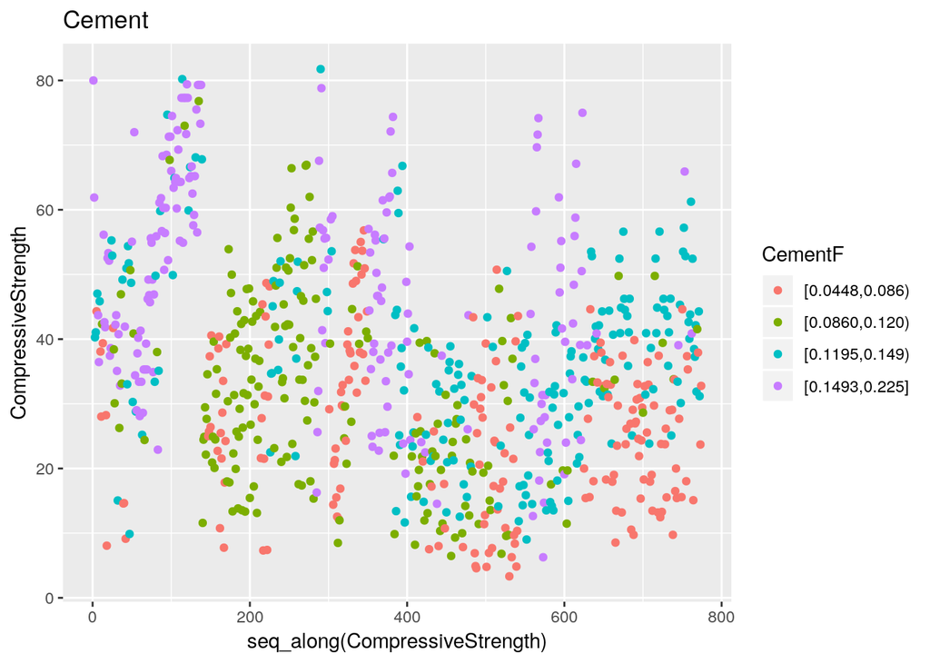

```r
qplot(x = seq_along(CompressiveStrength), y = CompressiveStrength, colour = CementF, data = training, main = "Cement")
```

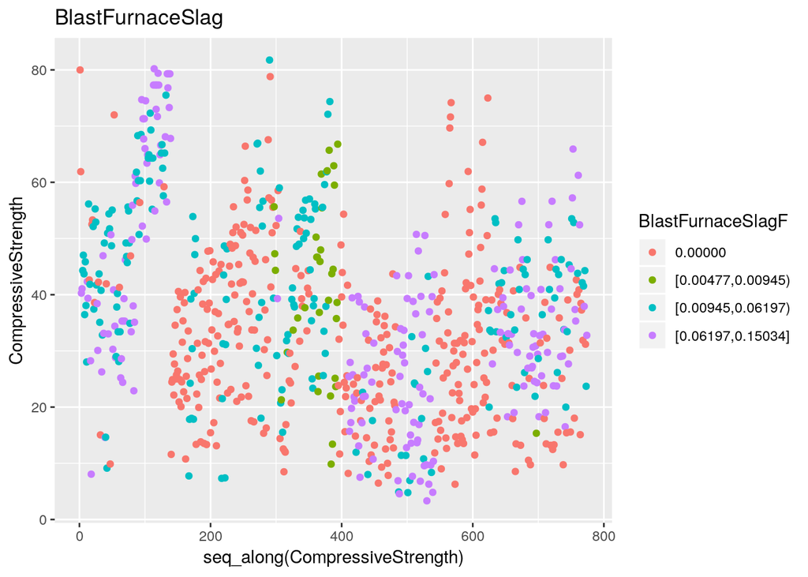

```r
qplot(x = seq_along(CompressiveStrength), y = CompressiveStrength, colour = BlastFurnaceSlagF, data = training, main = "BlastFurnaceSlag")
```

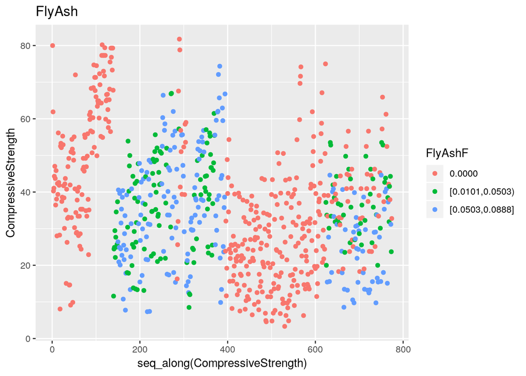

```r
qplot(x = seq_along(CompressiveStrength), y = CompressiveStrength, colour = FlyAshF, data = training, main = "FlyAsh")
```

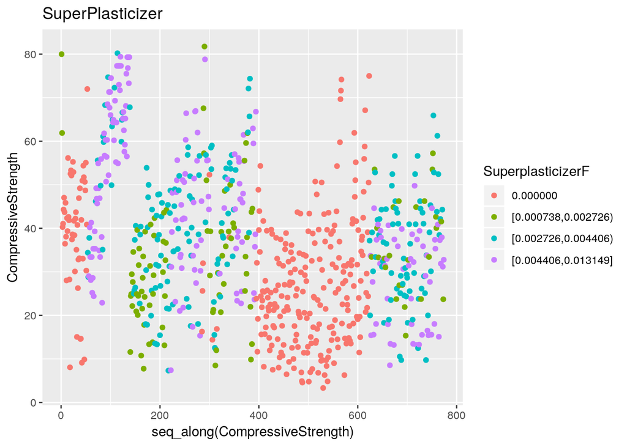

```r
qplot(x = seq_along(CompressiveStrength), y = CompressiveStrength, colour = SuperplasticizerF, data = training, main = "SuperPlasticizer")
```

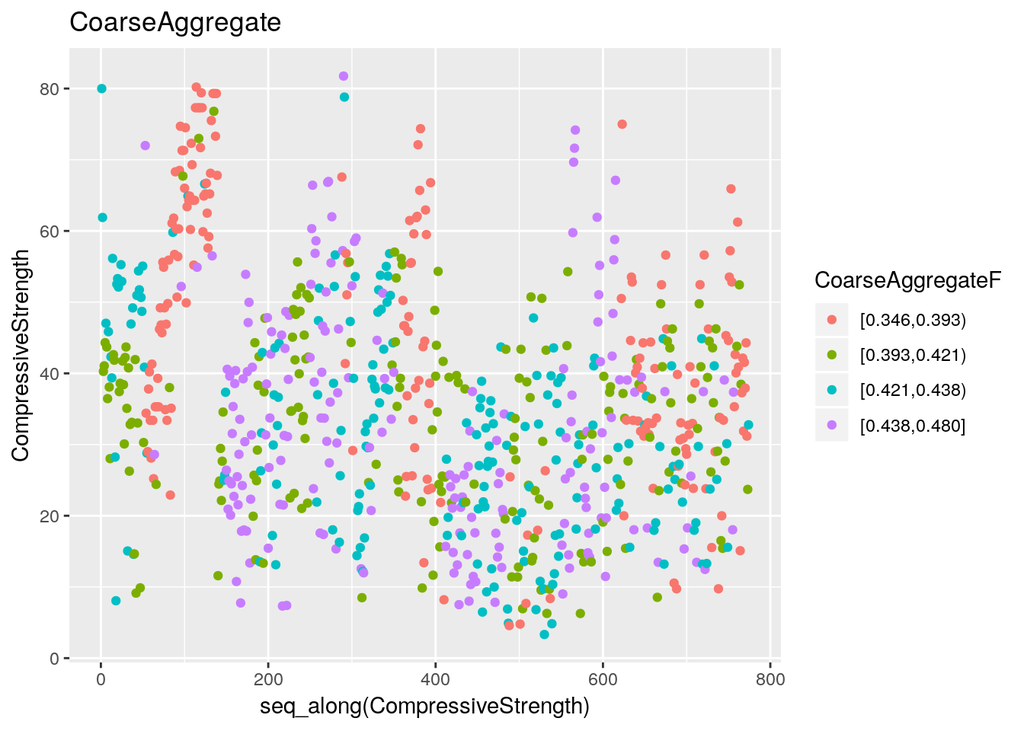

```r
qplot(x = seq_along(CompressiveStrength), y = CompressiveStrength, colour = CoarseAggregateF, data = training, main = "CoarseAggregate")
```

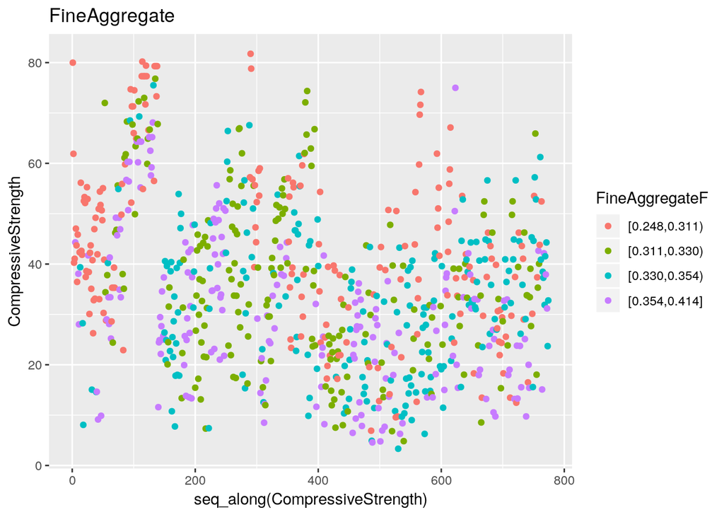

```r
qplot(x = seq_along(CompressiveStrength), y = CompressiveStrength, colour = FineAggregateF, data = training, main = "FineAggregate")
```

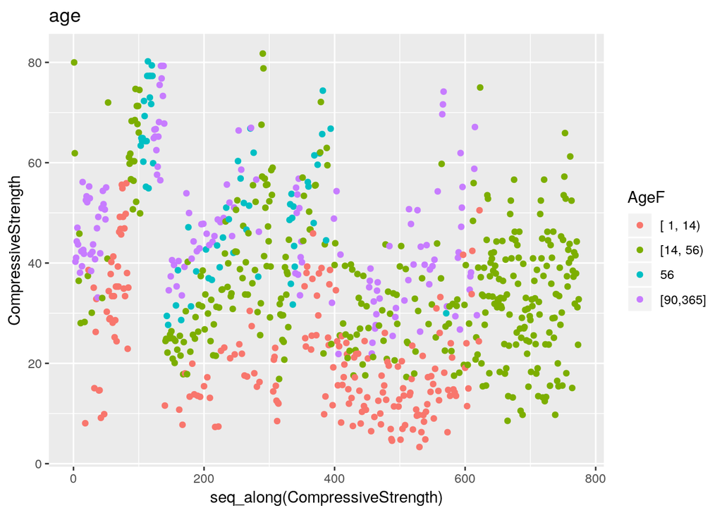

```r
qplot(x = seq_along(CompressiveStrength), y = CompressiveStrength, colour = AgeF, data = training, main = "age")
```

There is a non-random pattern in the plot of the outcome versus index that does not appear to be perfectly explained by any predictor suggesting a variable may be missing.

## Quesiton 3

```r
library(AppliedPredictiveModeling)
data(concrete)
library(caret)
set.seed(1000)
inTrain = createDataPartition(mixtures$CompressiveStrength, p = 3/4)[[1]]
training = mixtures[ inTrain,]
testing = mixtures[-inTrain,]
```

Make a histogram and confirm the SuperPlasticizer variable is skewed. Normally you might use the log transform to try to make the data more symmetric. Why would that be a poor choice for this variable?

```r
summary(training$Superplasticizer)
```

```
##     Min.  1st Qu.   Median     Mean  3rd Qu.     Max.
## 0.000000 0.000000 0.002723 0.002602 0.004396 0.013149
```

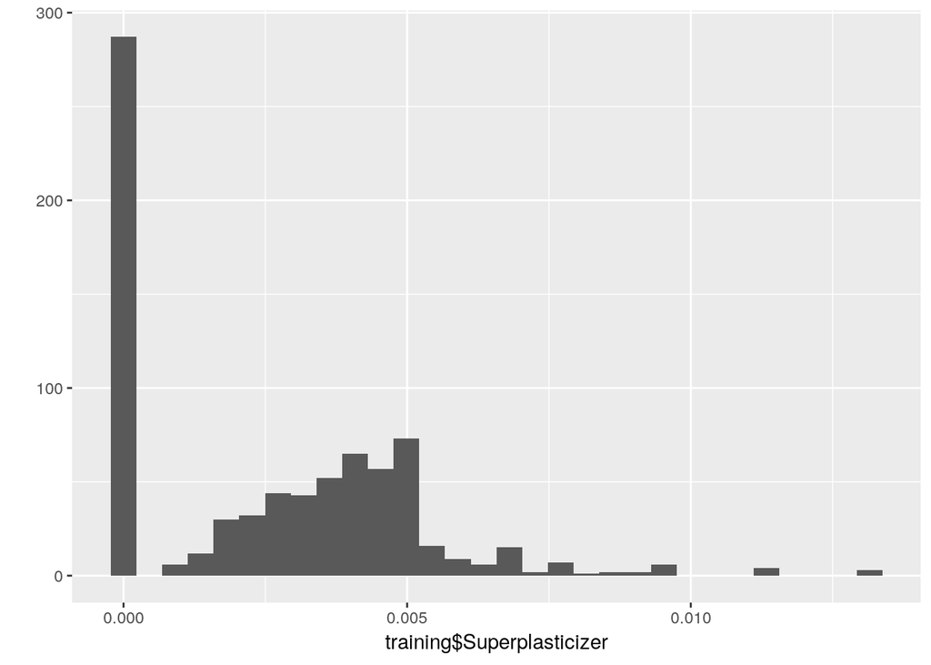

```r
qplot(training$Superplasticizer)
```

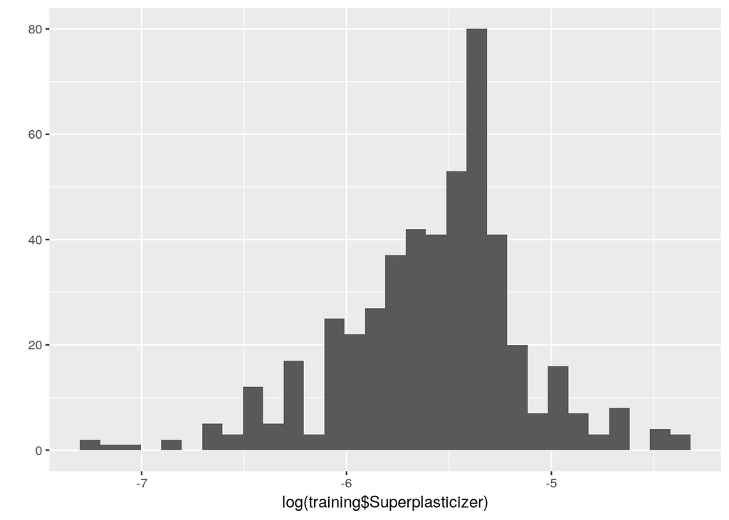

```r
qplot(log(training$Superplasticizer))
```

## Question 4

```r
library(caret)
library(AppliedPredictiveModeling)
set.seed(3433)
data(AlzheimerDisease)
adData = data.frame(diagnosis,predictors)
inTrain = createDataPartition(adData$diagnosis, p = 3/4)[[1]]
training = adData[ inTrain,]
testing = adData[-inTrain,]
```

Find all the predictor variables in the training set that begin with IL. Perform principal components on these variables with the preProcess() function from the caret package. Calculate the number of principal components needed to capture 90% of the variance. How many are there?

```r
library(caret)
ILvec <- training[, grep("^IL",names(training))]
preProcess(ILvec,method="pca", thresh = 0.9)
```

```
## Created from 251 samples and 12 variables
##
## Pre-processing:
##   - centered (12)
##   - ignored (0)
##   - principal component signal extraction (12)
##   - scaled (12)
##
## PCA needed 9 components to capture 90 percent of the variance
```

```r
temp <- svd(scale(ILvec))
sum((temp$d/sum(temp$d))[1:10])
```

```
## [1] 0.9079077
```

Interestingly I ge two different results.

## Question 5

```r
library(caret)
library(AppliedPredictiveModeling)
set.seed(3433)
data(AlzheimerDisease)
adData = data.frame(diagnosis,predictors)
inTrain = createDataPartition(adData$diagnosis, p = 3/4)[[1]]
training = adData[ inTrain,]
testing = adData[-inTrain,]
```

Create a training data set consisting of only the predictors with variable names beginning with IL and the diagnosis. Build two predictive models, one using the predictors as they are and one using PCA with principal components explaining 80% of the variance in the predictors. Use method=“glm” in the train function.

What is the accuracy of each method in the test set? Which is more accurate?

```r
ILvec <- training[, grep("^IL",names(training))]
preProc <- preProcess(ILvec,method="pca", thresh = 0.8)
trainPC <- predict(preProc,ILvec)
modelFitPCA <- train(x = trainPC, y = training$diagnosis, method="glm")

testPC <- predict(preProc,testing)
confusionMatrix(testing$diagnosis, predict(modelFitPCA,testPC))
```

```
## Confusion Matrix and Statistics
##
##           Reference
## Prediction Impaired Control
##   Impaired        1      21
##   Control         2      58
##
##                Accuracy : 0.7195
##                  95% CI : (0.6094, 0.8132)
##     No Information Rate : 0.9634
##     P-Value [Acc > NIR] : 1.0000000
##
##                   Kappa : 0.0167
##
##  Mcnemar's Test P-Value : 0.0001746
##
##             Sensitivity : 0.33333
##             Specificity : 0.73418
##          Pos Pred Value : 0.04545
##          Neg Pred Value : 0.96667
##              Prevalence : 0.03659
##          Detection Rate : 0.01220
##    Detection Prevalence : 0.26829
##       Balanced Accuracy : 0.53376
##
##        'Positive' Class : Impaired
##
```

```r
modelFit <- train(x = ILvec, y = training$diagnosis, method="glm")
confusionMatrix(testing$diagnosis, predict(modelFit,testing))
```

```
## Confusion Matrix and Statistics
##
##           Reference
## Prediction Impaired Control
##   Impaired        4      18
##   Control         2      58
##
##                Accuracy : 0.7561
##                  95% CI : (0.6488, 0.8442)
##     No Information Rate : 0.9268
##     P-Value [Acc > NIR] : 0.9999997
##
##                   Kappa : 0.1929
##
##  Mcnemar's Test P-Value : 0.0007962
##
##             Sensitivity : 0.66667
##             Specificity : 0.76316
##          Pos Pred Value : 0.18182
##          Neg Pred Value : 0.96667
##              Prevalence : 0.07317
##          Detection Rate : 0.04878
##    Detection Prevalence : 0.26829
##       Balanced Accuracy : 0.71491
##
##        'Positive' Class : Impaired
##
```